# Phase pickers across five earthquake sequences

| Sequence | Date | M | Setting |
| --- | --- | --- | --- |
| **Ridgecrest** | 2019-07-06 | 7.1 | Eastern California, dense aftershocks seconds apart |
| **San Simeon** | 2003-12-22 | 6.5 | Central Coast, 2003 network and instrumentation |
| **Monte Cristo** | 2020-05-15 | 6.5 | Nevada, Basin and Range, different network |
| **Mendocino** | 2024-12-05 | 7.0 | Offshore, one-sided geometry, every station 55 km+ |
| **Monroe WA** | 2019-07-12 | 4.6 | Cascadia, moderate magnitude |

Five stations each, chosen nearest-first among those that actually return data — several catalogued stations serve nothing for these dates, so the list was built by testing rather than from metadata.

### Weight sets

Four, and they are not one lineage. `original` is Zhu & Beroza, trained on Northern California. `jma_wc` is a wider architecture — PhaseNetWC, double the filters per layer — trained on Japanese data, and `quakescope2026` is fine-tuned from it. `instance` is separate again, and is what QuakeScope ran in production in 2025, which makes it the number any new choice has to beat.

| `quakescope2026` | the v7 fine-tune, this project's production candidate |
| --- | --- |
| `jma_wc` | the SeisBench Japanese model v7 was distilled from — the baseline that matters |
| `original` | Zhu & Beroza (2019), the published reference |
| `instance` | trained on the Italian INSTANCE dataset — **the weight the 2025 campaign actually ran**, so it is the incumbent rather than a control |

### How it is scored

Four of the five sequences have published analyst arrivals. Three of them are scored against the team's curated reviewed-event lists in `docs/rerun_2026/`, with arrivals harvested from every archive that located those events and restricted to manually reviewed picks — see section 4a for the provenance. **Recall is the metric; precision is not computed.** Analyst catalogs are not exhaustive — especially in dense aftershock sequences — so a model pick with no analyst counterpart may be a false positive or a real arrival nobody had time to mark. Those are reported as *extra detections* and never counted as errors.

Monroe WA has no published arrivals, so it is scored on **agreement between the models** instead. That measures consistency, not correctness.

```python
import io
from collections import Counter, defaultdict
from datetime import timezone
from pathlib import Path

import matplotlib.pyplot as plt
import numpy as np
import obspy
import pandas as pd
import seisbench.models as sbm
from obspy import UTCDateTime
from obspy.clients.fdsn import Client
from obspy.geodetics import gps2dist_azimuth
from s3fs import S3FileSystem

%matplotlib inline
```

## 1. Configuration

```python
# Five sequences, chosen to vary region, network, magnitude, and era.
# Stations were selected by testing that data actually returns, not from
# metadata alone - several catalogued stations serve nothing for these dates.
SEQUENCES = {
    "Ridgecrest": dict(
        time=UTCDateTime("2019-07-06T03:19:53"), lat=35.770, lon=-117.599, mag=7.1,
        picks_from=["SCEDC", "NCEDC"], min_mag=3.2, window_min=30,
        catalog_csv="comcat_reviewed_ridgecrest.csv",
        stations=[("CI", "CLC", "HH"), ("CI", "TOW2", "HH"), ("CI", "SRT", "HH"),
                  ("CI", "WRC2", "HH"), ("CI", "JRC2", "HH")],
        note="dense aftershock sequence, events seconds apart",
    ),
    "San Simeon": dict(
        time=UTCDateTime("2003-12-22T19:15:56"), lat=35.700, lon=-121.100, mag=6.5,
        picks_from=["SCEDC", "NCEDC"], min_mag=2.0, window_min=120,
        catalog_csv="comcat_reviewed_san_simeon.csv",
        stations=[("BK", "PKD", "HH"), ("CI", "PHL", "HH"), ("CI", "SMM", "HH"),
                  ("BK", "SAO", "HH"), ("CI", "LCP", "HH")],
        note="2003 - sparser network; SCEDC and NCEDC locate this one with "
             "different station sets, so both are queried",
    ),
    "Monte Cristo": dict(
        time=UTCDateTime("2020-05-15T11:03:27"), lat=38.169, lon=-117.850, mag=6.5,
        picks_from=["SCEDC", "NCEDC"], min_mag=2.0, window_min=120,
        stations=[("NN", "BRS2", "HH"), ("NN", "LHV", "HH"), ("NN", "ION4", "HH"),
                  ("NN", "DSP", "HH"), ("NN", "Q09A", "HH")],
        note="Nevada, Basin and Range - a different crust and a different network",
    ),
    "Mendocino 2024": dict(
        time=UTCDateTime("2024-12-05T18:44:21"), lat=40.374, lon=-125.022, mag=7.0,
        picks_from=["SCEDC", "NCEDC"], min_mag=2.0, window_min=120,
        catalog_csv="comcat_reviewed_mendocino.csv",
        stations=[("BK", "PETL", "HH"), ("NC", "KCT", "HH"), ("BK", "WLKR", "HH"),
                  ("NC", "KMPB", "HH"), ("BK", "RBOW", "HH")],
        note="offshore - every station is one-sided and 55 km or more away",
    ),
    "Monroe WA": dict(
        time=UTCDateTime("2019-07-12T09:51:38"), lat=47.873, lon=-122.016, mag=4.6,
        picks_from=None, min_mag=1.0, window_min=30,
        stations=[("UW", "SP2", "HH"), ("UW", "BERY", "HH"), ("UW", "RATT", "HH"),
                  ("UW", "BST16", "HH"), ("UW", "BST20", "HH")],
        note="Cascadia, moderate magnitude - no analyst arrivals published, so "
             "this one is scored on model agreement only",
    ),
}

# Each network is served by its home archive. Asking the wrong one silently
# returns nothing, which is how station lists end up looking empty.
#
# CI, BK and NC are read straight from the SCEDC and NCEDC public S3 buckets -
# the same path QuakeScope uses in production, and faster than FDSN. UW and NN
# have no equivalent open bucket, so they come over FDSN.
S3_BUCKET = {"CI": "scedc", "BK": "ncedc", "NC": "ncedc", "NP": "ncedc"}
ROUTE = {"CI": "SCEDC", "BK": "NCEDC", "NC": "NCEDC", "NP": "NCEDC",
         "UW": "EARTHSCOPE", "NN": "EARTHSCOPE", "LB": "EARTHSCOPE",
         "IM": "EARTHSCOPE"}

# Channel band, best first. 2003 is the reason this is a list: the SCEDC bucket
# carries only BH and LH for the CI stations that year, so a hard-coded HH
# would quietly drop them.
CHANNEL_PREFERENCE = ["HH", "BH"]

WEIGHTS = ["quakescope2026", "jma_wc", "original", "instance"]

# Aftershock window starts after the mainshock coda. Its length is set per
# sequence, because aftershock productivity and how much of it the analysts
# worked through vary enormously - 30 minutes at Ridgecrest yields a larger
# reference than two hours at San Simeon.
WINDOW_START = 600      # seconds after origin, all sequences

# Inference runs once at a low floor, keeping each pick's peak probability, so
# any threshold can be applied afterwards without re-running the models. The
# headline tables use REPORT_THRESHOLD; section 8 sweeps the rest.
DETECT_FLOOR = 0.02
REPORT_THRESHOLD = 0.3
THRESHOLD_SWEEP = [0.05, 0.1, 0.15, 0.2, 0.3, 0.4, 0.5, 0.6, 0.7]
MATCH_TOL = 0.5         # seconds, for counting an analyst pick as recovered

# CVD-validated categorical slots; every chart also carries direct value
# labels, so identity never rests on colour alone.
COLORS = ["#2a78d6", "#eb6834", "#1baf7a", "#eda100"]
C_P, C_S = "#2a78d6", "#eb6834"
```

## 2. Data access

CI, BK and NC are read directly from the **SCEDC and NCEDC public S3 buckets** — the same path QuakeScope uses in production, and faster than FDSN. UW and NN have no equivalent open bucket, so those come over FDSN, where each network still has to be asked of its *home* archive: requesting CI from EarthScope, or BK from SCEDC, returns nothing without raising.

The two buckets do not share a layout. SCEDC pads the station to five characters and the location to three and puts everything in one day folder; NCEDC makes the network a directory level and separates the day with a dot. Both conventions are implemented below.

Location codes are discovered rather than assumed. They are neither guessable nor consistent within an archive — on NCEDC in 2024 the BK stations use `00` while NC uses a blank — and hard-coding either returns nothing in a way that is indistinguishable from missing data. Listing the day prefix once solves that, tells us whether a channel exists before we request it, and sidesteps an s3fs trap: globbing populates the directory cache with only the matching entries, after which opening a sibling object raises `FileNotFoundError` even though it is there.

> **The buckets are not a mirror of FDSN for older data.** On San Simeon's day in 2003 the SCEDC bucket carries only BH and LH for the CI stations, while SCEDC's FDSN service serves HH for the same station-day. That is why the channel is a preference list rather than a fixed choice, and it is worth knowing for any campaign reading S3 over an older period — it will quietly see less than a web-service query would.

```python
_fs = S3FileSystem(anon=True)
_clients = {}


def _scedc_key(net, sta, cha, comp, year, doy, loc=""):
    """SCEDC: station padded to five, location padded to three, one file per channel-day."""
    base = f"{net}{sta.ljust(5, '_')}{cha}{comp}{loc.ljust(3, '_')}{year}{doy:03d}.ms"
    return f"scedc-pds/continuous_waveforms/{year}/{year}_{doy:03d}/{base}"


def _ncedc_key(net, sta, cha, comp, year, doy, loc=""):
    """NCEDC: network is a directory level and the day folder uses a dot."""
    return (f"ncedc-pds/continuous_waveforms/{net}/{year}/{year}.{doy:03d}/"
            f"{sta}.{net}.{cha}{comp}.{loc}.D.{year}.{doy:03d}")


_KEY_FN = {"scedc": _scedc_key, "ncedc": _ncedc_key}


_listings = {}


def _day_listing(bucket, net, year, doy):
    """Object names for one network-day, listed once and reused.

    Listing the whole day prefix rather than globbing per station does three
    things: it finds the location code instead of guessing it, it lets a
    missing channel be detected without a failed request, and it avoids an
    s3fs trap - a glob populates the directory cache with only the matching
    entries, after which opening a sibling object raises FileNotFoundError
    even though it exists.
    """
    if bucket == "scedc":
        prefix = f"scedc-pds/continuous_waveforms/{year}/{year}_{doy:03d}/"
    else:
        prefix = f"ncedc-pds/continuous_waveforms/{net}/{year}/{year}.{doy:03d}/"
    if prefix not in _listings:
        try:
            _listings[prefix] = {k.split("/")[-1] for k in _fs.ls(prefix)}
        except Exception:
            _listings[prefix] = set()
    return prefix, _listings[prefix]


def _object_name(bucket, net, sta, cha, comp, year, doy, names):
    """The object holding this channel-day, whatever its location code."""
    if bucket == "scedc":
        head = f"{net}{sta.ljust(5, '_')}{cha}{comp}"
        tail = f"{year}{doy:03d}.ms"
        hits = [n for n in names if n.startswith(head) and n.endswith(tail)]
    else:
        head = f"{sta}.{net}.{cha}{comp}."
        tail = f".D.{year}.{doy:03d}"
        hits = [n for n in names if n.startswith(head) and n.endswith(tail)]
    return sorted(hits)[0] if hits else None


def read_s3(net, sta, cha, t0, t1):
    """Whole-day objects from the public bucket, trimmed to the window."""
    bucket = S3_BUCKET.get(net)
    if bucket is None:
        return None
    year, doy = t0.year, int(t0.strftime("%j"))
    prefix, names = _day_listing(bucket, net, year, doy)
    if not names:
        return None
    st = obspy.Stream()
    for comp in "ZNE":
        name = _object_name(bucket, net, sta, cha, comp, year, doy, names)
        if name is None:
            return None                      # incomplete three-component set
        try:
            with _fs.open(prefix + name) as fh:
                st += obspy.read(io.BytesIO(fh.read()))
        except Exception:
            return None
    st.merge(fill_value=0)
    st.trim(t0, t1)
    return st if len(st) >= 3 else None


def client_for(net):
    """FDSN client for whichever archive holds this network."""
    provider = ROUTE.get(net, "EARTHSCOPE")
    if provider not in _clients:
        _clients[provider] = Client(provider, timeout=300)
    return _clients[provider]


def fetch_sequence(seq):
    """Waveforms for every station of one sequence, over the aftershock window."""
    t0 = seq["time"] + WINDOW_START
    t1 = t0 + seq["window_min"] * 60
    streams, rates = {}, {}
    for net, sta, _ in seq["stations"]:
        got = None
        for cha in CHANNEL_PREFERENCE:
            got = read_s3(net, sta, cha, t0, t1)          # bucket first
            if got is None and net not in S3_BUCKET:       # no bucket: FDSN
                try:
                    got = client_for(net).get_waveforms(net, sta, "*", cha + "?", t0, t1)
                    got.merge(fill_value=0)
                    if len(got) < 3:
                        got = None
                except Exception:
                    got = None
            if got is not None:
                break
        if got is None:
            print(f"    {net}.{sta}: no data")
            continue
        expected = seq["window_min"] * 60 * got[0].stats.sampling_rate
        if got[0].stats.npts < 0.5 * expected:
            print(f"    {net}.{sta}: incomplete")
            continue
        key = f"{net}.{sta}"
        streams[key] = got
        rates[key] = got[0].stats.sampling_rate
    return streams, t0, t1, rates


CATALOG_DIR = Path("../docs/rerun_2026")   # team-curated reviewed event lists
ORIGIN_LEAD = 180     # s: an origin this far before t0 can still put arrivals inside it
# Tolerance for calling two origins the same earthquake. Ridgecrest aftershocks
# arrive 0.35 s apart at the tightest, so time alone is not enough to identify an
# event: at 5 s, 17 returned origins matched more than one curated event and the
# coverage count silently undercounted. Requiring proximity too brings that to 2.
ORIGIN_TOL = 2.0      # s
ORIGIN_DIST_KM = 30.0
CATALOG_RADIUS = 1.5  # deg: generous, because the curated list does the filtering


def _curated_origins(seq, t0, t1):
    """Origin times of the team's reviewed events for this sequence."""
    df = pd.read_csv(CATALOG_DIR / seq["catalog_csv"])
    df = df[df["status"] == "reviewed"].copy()
    df["t"] = pd.to_datetime(df["time"], format="mixed", utc=True)
    lo = (t0 - ORIGIN_LEAD).datetime.replace(tzinfo=timezone.utc)
    hi = t1.datetime.replace(tzinfo=timezone.utc)
    sel = df[(df["t"] >= lo) & (df["t"] <= hi)]
    return [(UTCDateTime(r["t"].isoformat()), r["latitude"], r["longitude"])
            for _, r in sel.iterrows()]


def _match_curated(origin, curated):
    """Index of the curated event this origin is, or None. Nearest in time among
    those within both tolerances, so neighbouring aftershocks are not conflated."""
    best, best_dt = None, None
    for j, (ct, cla, clo) in enumerate(curated):
        dt = abs(origin.time - ct)
        if dt > ORIGIN_TOL:
            continue
        if gps2dist_azimuth(origin.latitude, origin.longitude,
                            cla, clo)[0] / 1000.0 > ORIGIN_DIST_KM:
            continue
        if best_dt is None or dt < best_dt:
            best, best_dt = j, dt
    return best


def analyst_picks(seq, t0, t1):
    """Reviewed analyst P and S picks in the window, keyed by (station, phase).

    The curated list in `docs/rerun_2026/comcat_reviewed_*.csv` decides **which
    earthquakes count** - every row is a `status == reviewed` ComCat origin the
    team selected. Arrivals are then harvested from **every** archive in
    `picks_from` that independently located those earthquakes, matched to the
    list by origin time within ORIGIN_TOL.

    Both halves matter. Anchoring the event set on a committed file is what
    makes the reference reproducible: an identical live radius/magnitude query
    returned 110 events one day and 123 another, because the event services
    serve a revisable catalog. Harvesting from every archive is what makes it
    complete: SCEDC and NCEDC locate the same California earthquake with
    different station sets, and ComCat carries only the authoritative solution.
    Taking the authoritative origin alone costs San Simeon 18 of its 20 S picks.

    Only `evaluation_mode == "manual"` picks are kept, so the reference is
    analyst work rather than the preliminary automatic picks the catalogs also
    carry. Duplicates are collapsed at MATCH_TOL, the tolerance used to score
    the models.
    """
    archives = seq["picks_from"]
    if not archives:
        return None
    if isinstance(archives, str):
        archives = [archives]
    curated = _curated_origins(seq, t0, t1) if seq.get("catalog_csv") else None
    keep = {f"{n}.{s}" for n, s, _ in seq["stations"]}

    out = defaultdict(list)
    stats = Counter()
    covered = set()
    for archive in archives:
        try:
            kwargs = dict(starttime=t0 - ORIGIN_LEAD, endtime=t1,
                          latitude=seq["lat"], longitude=seq["lon"],
                          includearrivals=True)
            if curated is None:      # no list: fall back to a magnitude floor
                kwargs.update(maxradius=1.0, minmagnitude=seq["min_mag"])
            else:
                kwargs.update(maxradius=CATALOG_RADIUS)
            cat = Client(archive, timeout=300).get_events(**kwargs)
        except Exception as exc:
            print(f"    {archive}: no catalog ({type(exc).__name__})")
            continue

        matched = added = 0
        for ev in cat:
            origin = ev.preferred_origin() or (ev.origins[0] if ev.origins else None)
            if origin is None:
                continue
            if curated is not None:
                hit = _match_curated(origin, curated)
                if hit is None:
                    stats["origin not in the curated list"] += 1
                    continue
                covered.add(hit)
            matched += 1
            by_id = {p.resource_id.id: p for p in ev.picks}
            for arr in origin.arrivals:
                pick = by_id.get(arr.pick_id.id)
                if pick is None or not arr.phase:
                    continue
                phase = arr.phase[0].upper()
                if phase not in ("P", "S"):
                    continue
                wid = pick.waveform_id
                key = f"{wid.network_code}.{wid.station_code}"
                if key not in keep or not (t0 <= pick.time <= t1):
                    continue
                if str(pick.evaluation_mode) == "automatic":
                    stats["automatic, dropped"] += 1
                    continue
                if any(abs(pick.time - u) <= MATCH_TOL for u in out[(key, phase)]):
                    stats["duplicate across archives"] += 1
                    continue
                out[(key, phase)].append(pick.time)
                added += 1
        note = f", {matched} matched the curated list" if curated is not None else ""
        print(f"    {archive}: {len(cat)} events{note}, +{added} picks on these stations")

    if curated is not None:
        print(f"    curated list: {len(covered)}/{len(curated)} reviewed events "
              f"located by at least one archive")
    if stats:
        print("    (" + ", ".join(f"{v} {k}" for k, v in stats.items()) + ")")
    return {k: sorted(v) for k, v in out.items()} if out else None


def at_threshold(store, thr):
    """Pick times from a (time, probability) store, at a given threshold."""
    return {k: sorted(t for t, v in vals if v >= thr) for k, vals in store.items()}


def match(reference, candidate, tol=MATCH_TOL):
    """Greedy nearest match; each candidate pick is consumed at most once."""
    used, residuals = set(), []
    for a in reference:
        best_i = best_d = None
        for i, m in enumerate(candidate):
            if i in used:
                continue
            d = m - a
            if abs(d) <= tol and (best_d is None or abs(d) < abs(best_d)):
                best_i, best_d = i, d
        if best_i is not None:
            used.add(best_i)
            residuals.append(best_d)
    return residuals, len(candidate) - len(used)
```

## 3. Load the weight sets

```python
available = sbm.PhaseNet.list_pretrained()
models = {}
for name in WEIGHTS:
    if name not in available:
        print(f"{name:<16} not installed - skipping")
        continue
    try:
        models[name] = sbm.PhaseNet.from_pretrained(name)
        print(f"{name:<16} loaded")
    except Exception as exc:
        print(f"{name:<16} could not load ({type(exc).__name__}) - skipping")

if not models:
    raise RuntimeError("no weight sets available")
names = list(models)
```

```
quakescope2026   loaded
jma_wc           loaded
original         loaded
instance         loaded
```

## 4. Run every model over every sequence

```python
results = {}
for label, seq in SEQUENCES.items():
    print(f"{label} (M{seq['mag']}, {seq['note']})")
    streams, t0, t1, rates = fetch_sequence(seq)
    print(f"    {len(streams)}/{len(seq['stations'])} stations: "
          + ", ".join(f"{k.split(chr(46))[1]}@{v:g}Hz" for k, v in rates.items()))
    if not streams:
        continue
    reference = analyst_picks(seq, t0, t1)
    if reference is not None:
        n_p = sum(len(v) for (_, ph), v in reference.items() if ph == 'P')
        n_s = sum(len(v) for (_, ph), v in reference.items() if ph == 'S')
        print(f"    analyst picks: {n_p} P, {n_s} S")
    else:
        print("    no analyst arrivals - model agreement only")

    picks = {}
    for name, model in models.items():
        per_station = defaultdict(list)
        for sta, st in streams.items():
            try:
                out = model.classify(st, P_threshold=DETECT_FLOOR,
                                     S_threshold=DETECT_FLOOR)
            except Exception as exc:
                print(f"    {name} {sta}: {type(exc).__name__}")
                continue
            for p in out.picks:
                per_station[(sta, p.phase)].append((p.peak_time, float(p.peak_value)))
        picks[name] = dict(per_station)
        tot = sum(1 for v in per_station.values() for t, q in v if q >= REPORT_THRESHOLD)
        print(f"    {name:<16} {tot} picks at {REPORT_THRESHOLD}")

    results[label] = dict(streams=streams, picks=picks, reference=reference,
                          t0=t0, t1=t1, rates=rates)
    print()
```

```
Ridgecrest (M7.1, dense aftershock sequence, events seconds apart)
```

```
    5/5 stations: CLC@100Hz, TOW2@100Hz, SRT@100Hz, WRC2@100Hz, JRC2@100Hz
```

```
    SCEDC: 141 events, 138 matched the curated list, +645 picks on these stations
```

```
    NCEDC: 2 events, 2 matched the curated list, +0 picks on these stations
    curated list: 138/138 reviewed events located by at least one archive
    (3 origin not in the curated list, 1 duplicate across archives)
    analyst picks: 347 P, 298 S
```

```
    quakescope2026   643 picks at 0.3
```

```
    jma_wc           617 picks at 0.3
```

```
    original         1010 picks at 0.3
```

```
    instance         198 picks at 0.3

San Simeon (M6.5, 2003 - sparser network; SCEDC and NCEDC locate this one with different station sets, so both are queried)
```

```
    5/5 stations: PKD@80Hz, PHL@20Hz, SMM@20Hz, SAO@80Hz, LCP@20Hz
```

```
    SCEDC: 19 events, 14 matched the curated list, +57 picks on these stations
```

```
    NCEDC: 108 events, 98 matched the curated list, +21 picks on these stations
    curated list: 98/98 reviewed events located by at least one archive
    (15 origin not in the curated list, 4 automatic, dropped, 10 duplicate across archives)
    analyst picks: 62 P, 16 S
```

```
    quakescope2026   564 picks at 0.3
```

```
    jma_wc           846 picks at 0.3
```

```
    original         788 picks at 0.3
```

```
    instance         414 picks at 0.3

Monte Cristo (M6.5, Nevada, Basin and Range - a different crust and a different network)
```

```
    5/5 stations: BRS2@100Hz, LHV@100Hz, ION4@100Hz, DSP@100Hz, Q09A@100Hz
```

```
    SCEDC: 5 events, +0 picks on these stations
```

```
    NCEDC: 48 events, +28 picks on these stations
    (18 automatic, dropped)
    analyst picks: 16 P, 12 S
```

```
    quakescope2026   1188 picks at 0.3
```

```
    jma_wc           1379 picks at 0.3
```

```
    original         1688 picks at 0.3
```

```
    instance         743 picks at 0.3

Mendocino 2024 (M7.0, offshore - every station is one-sided and 55 km or more away)
```

```
    5/5 stations: PETL@100Hz, KCT@100Hz, WLKR@100Hz, KMPB@100Hz, RBOW@100Hz
```

```
    SCEDC: 3 events, 0 matched the curated list, +0 picks on these stations
```

```
    NCEDC: 44 events, 44 matched the curated list, +313 picks on these stations
    curated list: 44/46 reviewed events located by at least one archive
    (3 origin not in the curated list, 3 automatic, dropped)
    analyst picks: 200 P, 113 S
```

```
    quakescope2026   851 picks at 0.3
```

```
    jma_wc           1154 picks at 0.3
```

```
    original         935 picks at 0.3
```

```
    instance         579 picks at 0.3

Monroe WA (M4.6, Cascadia, moderate magnitude - no analyst arrivals published, so this one is scored on model agreement only)
```

```
    5/5 stations: SP2@100Hz, BERY@100Hz, RATT@100Hz, BST16@100Hz, BST20@100Hz
    no analyst arrivals - model agreement only
```

```
    quakescope2026   64 picks at 0.3
```

```
    jma_wc           97 picks at 0.3
```

```
    original         54 picks at 0.3
```

```
    instance         37 picks at 0.3
```

## 4a. Where the reference picks come from

The waveforms and the reference picks come from different services, and it is worth being precise about the second because everything below is scored against it.

The picks are **arrivals attached to catalogued origins**, retrieved from the FDSN *event* service with `get_events(..., includearrivals=True)`. For each event the notebook walks `origin.arrivals`, resolves each `arrival.pick_id` back into `event.picks`, and keeps P and S whose `waveform_id` matches one of the five stations. A pick therefore exists in the reference only because an analyst made it **and** a location used it. This is not a standalone phase archive; there is no way to ask these services for "every pick on station X".

### What the QuakeML actually carries

Inspecting the returned objects rather than assuming:

| Field | Ridgecrest / SCEDC | San Simeon / NCEDC |
| --- | --- | --- |
| `evaluation_mode` | manual 3195, automatic 27 | manual 3977, automatic 36 |
| `evaluation_status` | reviewed 3195, preliminary 27 | final 3679, reviewed 298, preliminary 36 |
| `creation_info.agency_id` | `CI` (all) | `NC` (all) |
| `creation_info.author` | `None` (all) | `None` (all) |
| `method_id` | `None` (all) | `None` (all) |
| `onset` | emergent 2411, impulsive 799 | emergent 1197, impulsive 763, unset 2053 |
| `polarity` | undecidable 2783, positive 302, negative 137 | negative 1953, positive 1147, undecidable 913 |
| `time_errors.uncertainty` | set on all | set on all |

So the provenance is **institutional, not individual**. The agency is the regional network operator — `CI` for the Caltech/USGS Southern California Seismic Network via SCEDC, `NC` for the USGS/Berkeley Northern California network via NCEDC — and no analyst name is published. `method_id` is empty throughout, so the catalogs assert *that* a human reviewed the pick, not how.

`evaluation_status` distinguishes a first review (`reviewed`) from a closed catalog (`final`). The `creation_time` shows how long that takes: a Ridgecrest pick from the mainshock hour was created 2019-07-16, ten days later; a San Simeon NCEDC pick was created **2008-07-08**, nearly five years after the event, in a later reprocessing. These are revised catalogs, not real-time output.

What *is* per-pick and useful: `onset` (impulsive/emergent), `polarity` (first motion), and `time_errors.uncertainty` — the analyst's own timing uncertainty, 0.03 s on a sharp Ridgecrest P and 0.15 s on a 2003 San Simeon P. Those are quality flags this notebook does not yet use.

### Two consequences for the scoring

**Automatic picks are excluded.** The catalogs carry a preliminary automatic minority (27 of 3222 at Ridgecrest, 30 of 149 for SCEDC's San Simeon). Scoring a model against another algorithm's output is not what "analyst recall" should mean, so `analyst_picks()` drops `evaluation_mode == "automatic"`.

**Arrivals the locator did not use are kept.** `arrival.time_weight` is 0 for some picks — 37 of 106 S at Mendocino, 6 of 317 S at Ridgecrest — meaning the analyst marked the arrival but the location downweighted it out. Those are still real, human-identified arrivals, so a model that finds them is right and they stay in the reference.

### The event set comes from the team's curated lists

That matters for reproducibility. The previous version selected events with a live radius-and-magnitude query, and an identical Ridgecrest request returned **110 events one day and 123 another** — the event services serve a revisable catalog, so the denominator moved underneath the metric. Pinning the event set to a committed file removes that.

### Arrivals are harvested from every archive, not just the authoritative one

ComCat carries **one** solution per earthquake — the authoritative network's. For San Simeon that is `nc` on 1689 of 1692 rows, so following ComCat alone routes every event to NCEDC, whose solution never used the CI stations. SCEDC independently located the same earthquakes using them.

The cost of getting this wrong is large, on the same curated event set:

[output not shown]

Under the first, `CI.SMM` and `CI.LCP` contribute nothing at all and `BK.PKD` — NCEDC's own network — yields 3 P / 2 S instead of 14 P / 12 S. An earlier version of this notebook queried one archive and concluded San Simeon had "essentially no analyst S, which is 2003 practice"; that was an artifact of the archive choice, not a fact about 2003.

So the two halves do different jobs: the curated list decides *which earthquakes*, and the multi-archive harvest decides *how completely each one is observed*. The run prints how many curated events were located by at least one archive, which is the coverage check on the first half.

## 5. Recall against analyst picks

S is the phase worth watching. It is the harder pick, it constrains depth and location, and it is where the fine-tuning trade-offs surface.

```python
rows = []
for label, res in results.items():
    if res['reference'] is None:
        continue
    for name in names:
        if name not in res['picks']:
            continue
        thresholded = {name: at_threshold(res['picks'][name], REPORT_THRESHOLD)}
        for phase in ('P', 'S'):
            n_ref = n_hit = n_extra = 0
            residuals = []
            for sta in res['streams']:
                ref = res['reference'].get((sta, phase), [])
                got = thresholded[name].get((sta, phase), [])
                r, extra = match(ref, got)
                n_ref += len(ref); n_hit += len(r); n_extra += extra
                residuals += r
            if n_ref == 0:
                continue
            rows.append(dict(
                sequence=label, weights=name, phase=phase,
                analyst=n_ref, matched=n_hit,
                recall=round(n_hit / n_ref, 3),
                MAE=round(float(np.mean(np.abs(residuals))), 3) if residuals else np.nan,
                extra=n_extra,
            ))

bench = pd.DataFrame(rows)
if len(bench):
    print(bench.to_string(index=False))
else:
    print('no analyst-referenced results')
```

```
      sequence        weights phase  analyst  matched  recall   MAE  extra
    Ridgecrest quakescope2026     P      347      210   0.605 0.040    142
    Ridgecrest quakescope2026     S      298      154   0.517 0.053    137
    Ridgecrest         jma_wc     P      347      202   0.582 0.033    136
    Ridgecrest         jma_wc     S      298      145   0.487 0.064    134
    Ridgecrest       original     P      347      225   0.648 0.058    265
    Ridgecrest       original     S      298      216   0.725 0.066    304
    Ridgecrest       instance     P      347       75   0.216 0.048     25
    Ridgecrest       instance     S      298       54   0.181 0.079     44
    San Simeon quakescope2026     P       62       51   0.823 0.067    322
    San Simeon quakescope2026     S       16       12   0.750 0.020    179
    San Simeon         jma_wc     P       62       53   0.855 0.066    556
    San Simeon         jma_wc     S       16       12   0.750 0.035    225
    San Simeon       original     P       62       53   0.855 0.058    331
    San Simeon       original     S       16       15   0.938 0.103    389
    San Simeon       instance     P       62       55   0.887 0.083    243
    San Simeon       instance     S       16       12   0.750 0.094    104
  Monte Cristo quakescope2026     P       16       12   0.750 0.047    714
  Monte Cristo quakescope2026     S       12        5   0.417 0.219    457
  Monte Cristo         jma_wc     P       16       13   0.812 0.051    856
  Monte Cristo         jma_wc     S       12        6   0.500 0.236    504
  Monte Cristo       original     P       16       13   0.812 0.049    734
  Monte Cristo       original     S       12        8   0.667 0.146    933
  Monte Cristo       instance     P       16       14   0.875 0.089    453
  Monte Cristo       instance     S       12        6   0.500 0.174    270
Mendocino 2024 quakescope2026     P      200      166   0.830 0.071    318
Mendocino 2024 quakescope2026     S      113       70   0.619 0.086    297
Mendocino 2024         jma_wc     P      200      180   0.900 0.074    544
Mendocino 2024         jma_wc     S      113       77   0.681 0.101    353
Mendocino 2024       original     P      200      136   0.680 0.119    283
Mendocino 2024       original     S      113       83   0.735 0.124    433
Mendocino 2024       instance     P      200      168   0.840 0.089    199
Mendocino 2024       instance     S      113       63   0.558 0.120    149
```

```python
if len(bench):
    for phase in ('S', 'P'):
        sub = bench[bench.phase == phase]
        if not len(sub):
            continue
        piv = sub.pivot(index='sequence', columns='weights', values='recall')
        piv = piv.reindex(columns=[n for n in names if n in piv.columns])
        print(f'\n{phase} recall by sequence')
        print(piv.to_string())
```

```
S recall by sequence
weights         quakescope2026  jma_wc  original  instance
sequence
Mendocino 2024           0.619   0.681     0.735     0.558
Monte Cristo             0.417   0.500     0.667     0.500
Ridgecrest               0.517   0.487     0.725     0.181
San Simeon               0.750   0.750     0.938     0.750

P recall by sequence
weights         quakescope2026  jma_wc  original  instance
sequence
Mendocino 2024           0.830   0.900     0.680     0.840
Monte Cristo             0.750   0.812     0.812     0.875
Ridgecrest               0.605   0.582     0.648     0.216
San Simeon               0.823   0.855     0.855     0.887
```

### S recall, side by side

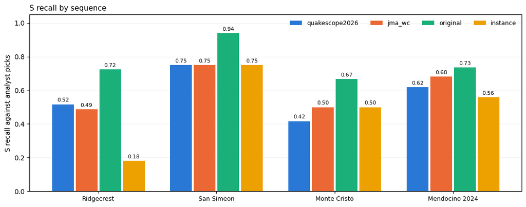

```python
if len(bench):
    sub = bench[bench.phase == 'S']
    seqs = [s for s in SEQUENCES if s in set(sub.sequence)]
    fig, ax = plt.subplots(figsize=(11, 4.4))
    width = 0.8 / max(len(names), 1)
    for i, name in enumerate(names):
        vals, xs = [], []
        for j, s in enumerate(seqs):
            row = sub[(sub.sequence == s) & (sub.weights == name)]
            if len(row):
                vals.append(float(row['recall'].iloc[0]))
                xs.append(j + (i - (len(names) - 1) / 2) * width)
        bars = ax.bar(xs, vals, width=width * 0.92, color=COLORS[i], label=name)
        for x, v in zip(xs, vals):
            ax.text(x, v + 0.015, f'{v:.2f}', ha='center', fontsize=8)
    ax.set_xticks(range(len(seqs)))
    ax.set_xticklabels(seqs, fontsize=9)
    ax.set_ylabel('S recall against analyst picks')
    ax.set_ylim(0, 1.05)
    ax.grid(alpha=0.25, lw=0.5, axis='y')
    ax.set_axisbelow(True)
    ax.legend(frameon=False, fontsize=9, ncol=len(names))
    ax.set_title('S recall by sequence', fontsize=11, loc='left')
    fig.tight_layout()
    plt.show()
```

## 6. Monroe WA — agreement without a reference

With no published arrivals, the only thing measurable is whether the models agree with each other. High agreement is not evidence of correctness; disagreement is evidence that at least one is wrong.

```python
no_ref = [l for l, r in results.items() if r['reference'] is None]
for label in no_ref:
    res = results[label]
    print(f'{label}')
    for name in names:
        if name not in res['picks']:
            continue
        thr_v = at_threshold(res['picks'][name], REPORT_THRESHOLD)
        p = sum(len(v) for (_, ph), v in thr_v.items() if ph == 'P')
        s = sum(len(v) for (_, ph), v in thr_v.items() if ph == 'S')
        print(f'    {name:<16} {p:4d} P, {s:4d} S')
    print()
    pairs = [(a, b) for i, a in enumerate(names) for b in names[i + 1:]]
    rows = []
    for a, b in pairs:
        if a not in res['picks'] or b not in res['picks']:
            continue
        for phase in ('P', 'S'):
            shared = tot_a = 0
            for sta in res['streams']:
                pa = at_threshold(res['picks'][a], REPORT_THRESHOLD).get((sta, phase), [])
                pb = at_threshold(res['picks'][b], REPORT_THRESHOLD).get((sta, phase), [])
                r, _ = match(pa, pb)
                shared += len(r); tot_a += len(pa)
            rows.append(dict(pair=f'{a} vs {b}', phase=phase,
                             shared=shared, of_first=tot_a,
                             frac=round(shared / tot_a, 3) if tot_a else np.nan))
    print(pd.DataFrame(rows).to_string(index=False))
    print('\nfrac = fraction of the first model\'s picks that the second also found,'
          f' within {MATCH_TOL} s')
```

```
Monroe WA
    quakescope2026     39 P,   25 S
    jma_wc             60 P,   37 S
    original           24 P,   30 S
    instance           25 P,   12 S

                      pair phase  shared  of_first  frac
  quakescope2026 vs jma_wc     P      34        39 0.872
  quakescope2026 vs jma_wc     S      24        25 0.960
quakescope2026 vs original     P      21        39 0.538
quakescope2026 vs original     S      17        25 0.680
quakescope2026 vs instance     P      19        39 0.487
quakescope2026 vs instance     S       9        25 0.360
        jma_wc vs original     P      22        60 0.367
        jma_wc vs original     S      23        37 0.622
        jma_wc vs instance     P      20        60 0.333
        jma_wc vs instance     S       9        37 0.243
      original vs instance     P      17        24 0.708
      original vs instance     S      11        30 0.367

frac = fraction of the first model's picks that the second also found, within 0.5 s
```

## 7. What the picks look like

One record section per sequence, from the model with the most picks, so the numbers above can be checked against the waveforms they came from. Aftershocks appear as separate moveout trains across the window.

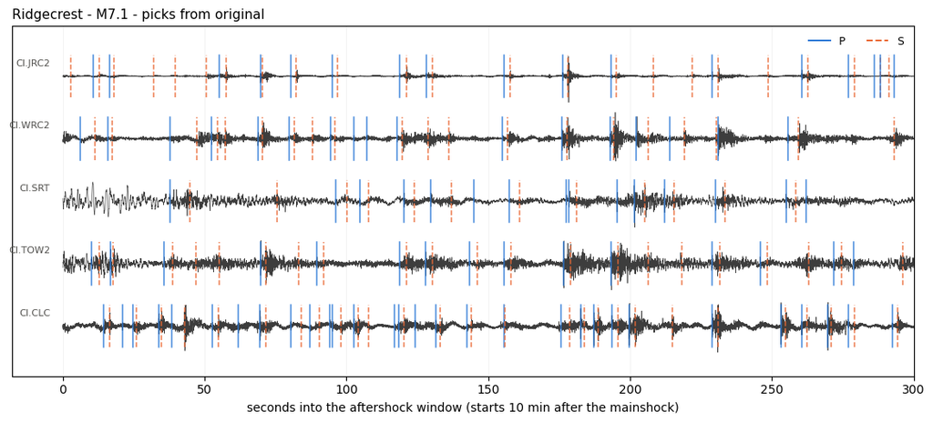

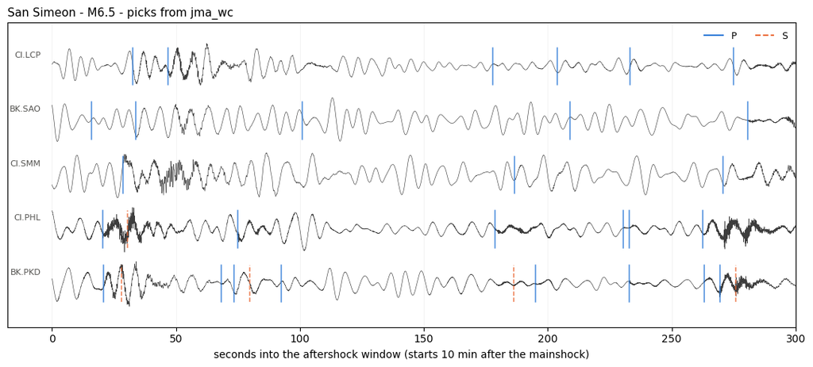

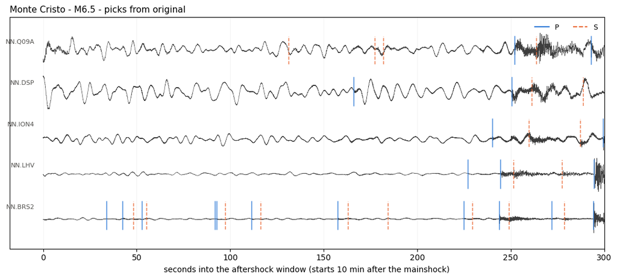

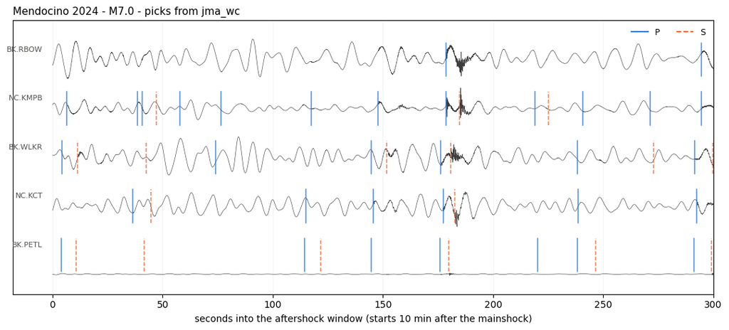

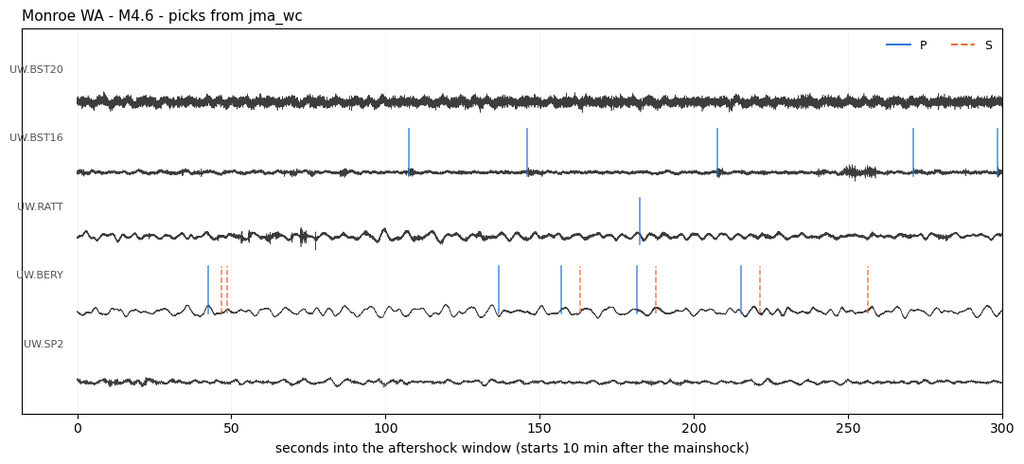

```python
def record_section(label, res, weight, span=300):
    seq = SEQUENCES[label]
    fig, ax = plt.subplots(figsize=(11, 5))
    order = sorted(res['streams'],
                   key=lambda s: [f'{n}.{t}' for n, t, _ in seq['stations']].index(s)
                   if s in [f'{n}.{t}' for n, t, _ in seq['stations']] else 99)
    for row, sta in enumerate(order):
        tr = res['streams'][sta].select(component='Z')
        if not tr:
            continue
        tr = tr[0].copy()
        tr.trim(res['t0'], res['t0'] + span)
        x = tr.data.astype(float)
        peak = np.abs(x).max()
        if peak > 0:
            x = x / peak * 0.42
        ax.plot(tr.times(), x + row, color='#3d3d3d', lw=0.45)
        ax.annotate(sta, (-span * 0.015, row + 0.16), fontsize=8,
                    color='#52514e', ha='right')
        for (s2, phase), times in at_threshold(res['picks'][weight], REPORT_THRESHOLD).items():
            if s2 != sta:
                continue
            for t in times:
                dt = t - res['t0']
                if 0 <= dt <= span:
                    ax.plot([dt, dt], [row - 0.34, row + 0.34],
                            color=C_P if phase == 'P' else C_S,
                            lw=1.1, ls='-' if phase == 'P' else '--', alpha=0.85)
    handles = [plt.Line2D([], [], color=C_P, lw=1.4, label='P'),
               plt.Line2D([], [], color=C_S, lw=1.4, ls='--', label='S')]
    ax.legend(handles=handles, frameon=False, fontsize=9, ncol=2, loc='upper right')
    ax.set_xlim(-span * 0.06, span)
    ax.set_ylim(-0.8, len(order) - 0.2)
    ax.set_yticks([])
    ax.set_xlabel(f'seconds into the aftershock window '
                  f'(starts {WINDOW_START // 60} min after the mainshock)')
    ax.set_title(f'{label} - M{seq["mag"]} - picks from {weight}',
                 fontsize=11, loc='left')
    ax.grid(alpha=0.2, lw=0.5, axis='x')
    fig.tight_layout()
    return fig


for label, res in results.items():
    best = max(res['picks'], key=lambda n: sum(
        1 for v in res['picks'][n].values() for t, q in v if q >= REPORT_THRESHOLD))
    record_section(label, res, best)
    plt.show()
```

## 8. Is one model better, or just more liberal?

Everything above uses a single threshold of 0.3 for every weight set. That is the convention, and it is misleading: the SeisBench model cards say so explicitly — *"threshold selected for optimal F1 on in-domain evaluation; depending on the target region, the thresholds might need to be adjusted"*. A model whose probabilities sit higher will emit more picks at the same nominal cutoff, and collect both more recall and more extra detections for it.

The fair comparison holds the **budget** fixed rather than the threshold: at the same number of picks emitted, which model recovers more of the analyst catalog?

```python
sweep_rows = []
for label, res in results.items():
    if res['reference'] is None:
        continue
    for name in names:
        if name not in res['picks']:
            continue
        for thr in THRESHOLD_SWEEP:
            view = at_threshold(res['picks'][name], thr)
            for phase in ('P', 'S'):
                hit = tot = emitted = 0
                for sta in res['streams']:
                    ref = res['reference'].get((sta, phase), [])
                    got = view.get((sta, phase), [])
                    r, _ = match(ref, got)
                    hit += len(r); tot += len(ref); emitted += len(got)
                if tot < 20:          # too few analyst picks to be meaningful
                    continue
                sweep_rows.append(dict(sequence=label, weights=name, phase=phase,
                                       thr=thr, recall=hit / tot, emitted=emitted))
sweep = pd.DataFrame(sweep_rows)
print(f'{len(sweep)} rows; sequences with enough analyst picks to sweep: '
      f"{sorted(set(sweep.sequence))}")
```

```
180 rows; sequences with enough analyst picks to sweep: ['Mendocino 2024', 'Ridgecrest', 'San Simeon']
```

```python
def matched_budget(sweep, phase, sequence, n_points=4):
    """Recall for each model at a common number of emitted picks."""
    sub = sweep[(sweep.phase == phase) & (sweep.sequence == sequence)]
    present = [n for n in names if n in set(sub.weights)]
    if len(present) < 2:
        return None
    lo = max(sub[sub.weights == n].emitted.min() for n in present)
    hi = min(sub[sub.weights == n].emitted.max() for n in present)
    if not np.isfinite([lo, hi]).all() or hi <= lo:
        ceiling = min(present, key=lambda n: sub[sub.weights == n].emitted.max())
        cap = int(sub[sub.weights == ceiling].emitted.max())
        print(f'{sequence}: no common budget - {ceiling} tops out at {cap} picks, '
              f'below where the others start. See the saturation table.')
        return None
    rows = []
    for target in np.linspace(lo, hi, n_points):
        row = {'picks_emitted': int(round(target))}
        for n in present:
            d = sub[sub.weights == n].sort_values('emitted')
            row[n] = round(float(np.interp(target, d.emitted, d.recall)), 3)
        rows.append(row)
    return pd.DataFrame(rows)


for sequence in sorted(set(sweep.sequence)):
    tab = matched_budget(sweep, 'S', sequence)
    if tab is None:
        continue
    print(f'{sequence} - S recall at matched pick budgets')
    print(tab.to_string(index=False))
    print()
```

```
Mendocino 2024 - S recall at matched pick budgets
 picks_emitted  quakescope2026  jma_wc  original  instance
           141           0.396   0.372     0.389     0.483
           261           0.528   0.519     0.553     0.606
           380           0.627   0.635     0.665     0.675
           500           0.692   0.709     0.727     0.761

Ridgecrest: no common budget - instance tops out at 193 picks, below where the others start. See the saturation table.
```

[figure not shown]

```python
seqs = [s for s in sorted(set(sweep.sequence))]
fig, axes = plt.subplots(1, len(seqs), figsize=(5.3 * len(seqs), 4.2), squeeze=False)
for ax, sequence in zip(axes[0], seqs):
    sub = sweep[(sweep.phase == 'S') & (sweep.sequence == sequence)]
    for name, color in zip(names, COLORS):
        d = sub[sub.weights == name].sort_values('emitted')
        if not len(d):
            continue
        ax.plot(d.emitted, d.recall, marker='o', ms=4, lw=1.8,
                color=color, label=name)
        star = d[np.isclose(d.thr, REPORT_THRESHOLD)]
        if len(star):
            ax.plot(star.emitted, star.recall, marker='*', ms=15,
                    color=color, mec='#16150f', mew=0.6, zorder=5)
    ax.set_title(f'{sequence} - S', fontsize=11, loc='left')
    ax.set_xlabel('S picks emitted')
    ax.grid(alpha=0.25, lw=0.5)
axes[0][0].set_ylabel('recall against analyst picks')
axes[0][0].legend(frameon=False, fontsize=9)
fig.suptitle('Same curve, different operating points - stars mark the shared 0.3 threshold',
             fontsize=10, x=0.01, ha='left')
fig.tight_layout()
plt.show()
```

### Can every model reach the same budget?

Matching on budget only works where the budgets overlap. If a model cannot emit as many picks as the others *even with its threshold on the floor*, that is a ceiling rather than a calibration offset, and the two have opposite implications: a calibration offset is fixed by tuning, a ceiling is not.

```python
sat_rows = []
for label, res in results.items():
    for name in names:
        if name not in res['picks']:
            continue
        row = {'sequence': label, 'weights': name}
        for thr in (DETECT_FLOOR, 0.1, REPORT_THRESHOLD):
            view = at_threshold(res['picks'][name], thr)
            row[f'S@{thr}'] = sum(len(v) for (_, ph), v in view.items() if ph == 'S')
        sat_rows.append(row)
sat = pd.DataFrame(sat_rows)
print('S picks emitted, by threshold')
print(sat.to_string(index=False))
print(f'\nS@{DETECT_FLOOR} is the ceiling: what the model finds with the threshold'
      ' on the floor.')
```

```
S picks emitted, by threshold
      sequence        weights  S@0.02  S@0.1  S@0.3
    Ridgecrest quakescope2026     684    459    291
    Ridgecrest         jma_wc     638    447    279
    Ridgecrest       original     832    646    520
    Ridgecrest       instance     246    149     98
    San Simeon quakescope2026    1265    579    191
    San Simeon         jma_wc    1546    726    237
    San Simeon       original     986    640    404
    San Simeon       instance     571    277    116
  Monte Cristo quakescope2026    1482    922    462
  Monte Cristo         jma_wc    1594   1023    510
  Monte Cristo       original    1952   1352    941
  Monte Cristo       instance     823    558    276
Mendocino 2024 quakescope2026    1267    757    367
Mendocino 2024         jma_wc    1555    914    430
Mendocino 2024       original    1036    726    516
Mendocino 2024       instance     659    398    212
     Monroe WA quakescope2026     138     56     25
     Monroe WA         jma_wc     215     85     37
     Monroe WA       original     137     58     30
     Monroe WA       instance      37     20     12

S@0.02 is the ceiling: what the model finds with the threshold on the floor.
```

### Export for the consolidated benchmark

Writes the tables above to `docs/benchmark/results/` so that `tutorials/benchmark_summary.ipynb` reads executed output.

```python
# Export the result tables for docs/benchmark/. The consolidated benchmark
# (tutorials/benchmark_summary.ipynb) reads these files rather than numbers
# transcribed from a rendered report, so every figure there traces to an
# executed cell here. Defensive on purpose: a missing table is reported, not fatal.
import datetime as _dt, json as _json
from pathlib import Path as _Path
import seisbench as _sb
_OUT = _Path("../docs/benchmark/results/us_sequences"); _OUT.mkdir(parents=True, exist_ok=True)
_written = []
def _export(name, obj):
    try:
        (obj.to_csv(_OUT / f"{name}.csv", index=isinstance(obj.index, pd.MultiIndex) or obj.index.name is not None)
         if hasattr(obj, "to_csv") else (_OUT / f"{name}.json").write_text(_json.dumps(obj, indent=1, default=str)))
        _written.append(name)
    except Exception as _exc:
        print(f"{name}: not exported ({type(_exc).__name__}: {_exc})")

_export("recall_at_threshold", bench)
_export("threshold_sweep", sweep)
_export("saturation", sat)
# Raw picks, so every metric can be recomputed without re-running inference.
# One row per model pick at the detection floor with its peak confidence, and
# one per reference arrival. docs/benchmark/README.md scores these with
# sb_catalog.src.benchmark_metrics; keeping them means a new metric costs a
# read rather than twenty-five minutes of inference.
_rows = []
for _label, _res in results.items():
    for _name, _store in _res["picks"].items():
        for (_sta, _pha), _v in _store.items():
            for _t, _q in _v:
                _rows.append(dict(sequence=_label, weights=_name, station=_sta, phase=_pha,
                                  time=pd.Timestamp(_t.datetime), conf=float(_q)))
_picks = pd.DataFrame(_rows)
_export("model_picks", _picks)

_rows = []
for _label, _res in results.items():
    # A sequence with no published arrivals (Monroe WA) is scored on model
    # agreement only and carries no reference.
    for (_sta, _pha), _v in (_res["reference"] or {}).items():
        for _t in _v:
            _rows.append(dict(sequence=_label, station=_sta, phase=_pha,
                              time=pd.Timestamp(_t.datetime)))
_ref = pd.DataFrame(_rows)
_export("reference_picks", _ref)
print(f"exported {len(_picks):,} model picks at the {DETECT_FLOOR} floor and {len(_ref):,} reference arrivals")

_meta = dict(notebook="phasenet_sequence_comparison.ipynb",
             executed=_dt.datetime.now(_dt.timezone.utc).isoformat(timespec="seconds"),
             seisbench=_sb.__version__, weights=WEIGHTS, report_threshold=REPORT_THRESHOLD,
             detect_floor=DETECT_FLOOR, match_tol_s=MATCH_TOL, window_start_s=WINDOW_START,
             sequences={k: dict(time=str(v["time"]), mag=v["mag"], lat=v["lat"], lon=v["lon"],
                                window_min=v["window_min"], picks_from=v["picks_from"],
                                catalog_csv=v.get("catalog_csv"),
                                stations=[".".join(s[:2]) for s in v["stations"]])
                        for k, v in SEQUENCES.items()})
_export("meta", _meta)
print("wrote", ", ".join(_written), "to", _OUT)
```

```
exported 41,579 model picks at the 0.02 floor and 1,064 reference arrivals
wrote recall_at_threshold, threshold_sweep, saturation, model_picks, reference_picks, meta to ../docs/benchmark/results/us_sequences
```

### What the curves say

At matched budgets the separation largely disappears between `quakescope2026`, `jma_wc` and `original`. Whatever ordering survives is within a few points and does not hold across sequences, which is another way of saying those three are close on this task and the threshold was doing the talking.

**`instance` is a different case, and the distinction matters.** On Mendocino it matches on budget and is competitive. On Ridgecrest it never reaches the others' budgets at all — the saturation table shows it topping out well below them with its threshold on the floor. That is a ceiling rather than a calibration offset: no threshold recovers it. Ridgecrest is the densest and closest-in sequence here, so the reading is that the incumbent weight struggles specifically with heavily overlapping near-field aftershocks, and is fine at regional distance.

**The operational consequence is that thresholds have to be set per weight set, and per region.** Carrying 0.3 across a change of weights silently moves the operating point and changes catalog completeness with it. Pick the target — a pick budget, an acceptable extra-detection rate, a recall floor — then solve for the threshold that hits it, separately for each weight set.

## Reading the result

**Read section 8 before ranking anything.** At the shared 0.3 threshold used in section 5, `original` looks clearly ahead on S recall at every sequence. At matched pick budgets that lead essentially vanishes: the three weight sets trace the same recall curve and differ mainly in where 0.3 places them on it. The apparent ranking was a calibration difference, not a capability one.

**Consistency across sequences still matters more than any single number.** A weight set that leads in one region and collapses in another is a worse production choice than one that is second everywhere, because a campaign runs over whatever the archives contain.

**The sequences are not equally difficult, by design.** Ridgecrest has stations within 5 km; Mendocino is offshore with nothing closer than 55 km and one-sided geometry; San Simeon is a 2003 network. Absolute recall is expected to differ between them, so read down each column, not across.

**Extra detections are not errors.** In a sequence producing hundreds of events an hour, most unmatched picks are real earthquakes the analysts never worked through. Separating those from false positives needs association across stations, which is a different exercise.

For how these weights were selected and what that selection cost, see `docs/phasenet_v7_model_description.md`.